This repository contains the R codes used in the demographic analysis of COVID-19 patients in Hong Kong in the project entitled with “The impact of economic and demographic conditions on COVID-19 diagnosis delays and deaths in Hong Kong”.

To generate the required graphs, you will need to run all the packages/codes mentioned in the top 18 lines of code. You can run all the codes in the R script to generate the demographic figures used in the project. If there are no such packages, make sure to install these packages first (e.g. install.packages()).

```r
library(ggplot2)
library(plyr)
library(ggpubr)
library(data.table)
library(carData)
library(car)
library(pscl)
library(ggrepel)
library(patchwork)
library(reshape2)
library(dplyr)
library(lubridate)
library(reshape2)
library(scales)
library(forcats)
library(corrplot)
library(Hmisc)
options(ggrepel.max.overlaps = Inf)
```

Next, read the data sources and setup certain initial conditions.

```r
# District & Territory Demographic
DD<-read.csv("data/dis_inc_cfr.csv")
DS<-read.csv("data/dis_inc_cfr_symptomatic.csv")
TS<-read.csv("data/Territory_symptomatic.csv")
Covid2<-read.csv("data/Covid model_symptomatic.csv")
```

```r
#Data Management
Covid2_Elderly<-Covid2%>%group_by(Age)%>%filter(any(Age>64))
Covid2_Elderly_Death<-Covid2_Elderly%>%group_by(event)%>%filter(any(event=="1"))
Covid2_Elderly_Cases.in.district<-Covid2_Elderly%>%group_by(district)%>%dplyr::summarise(Total=n()) # use dplyr::summarise
Covid2_Elderly_Death.in.district<-Covid2_Elderly_Death%>%group_by(district)%>%dplyr::summarise(Death=n())
new_row1 = list("Tai Po",0)
new_row2 = list(district="Sai Kung",Death=0)
Covid2_Elderly_Death.in.district = rbind(Covid2_Elderly_Death.in.district,new_row1)
Covid2_Elderly_Death.in.district = rbind(Covid2_Elderly_Death.in.district,new_row2)
Covid2_Elderly.in.district=left_join(Covid2_Elderly_Cases.in.district, Covid2_Elderly_Death.in.district)
Covid2_Elderly.in.district<-Covid2_Elderly.in.district%>%mutate(CFR_elderly=round(Death/Total*100,2))
colnames(Covid2_Elderly.in.district)[c(1)]<-c("District")
CFR_Overview=left_join(Covid2_Elderly.in.district, DS)
CFR_Overview<-subset(CFR_Overview,select =c(District,CFR_elderly,cfr_percent,income_trans,population_density))
```

The Project Code_Demographic Analysis.R is divided into 4 different parts: -The sampling distribution of COVID-19 cases & death. -The demographic analysis of district/territory -The correlation matrix among COVID-19 patients -The case fatality rate (CFR) among reporting delay & hospitalization time

### Sampling distribution

To see the sampling distributions of the daily number of confirmed cases and number of deaths, run the following r codes.You can reproduce the corresponding time series plot also.

#Incidence and daily deaths

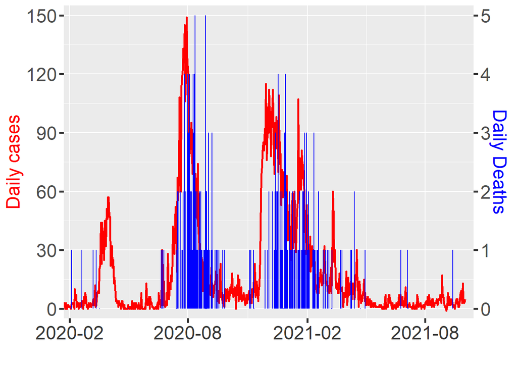

```r
Latest<-read.csv("data/Latest Situation.csv")

Latest$Report.date<-dmy(Latest$Report.date)
Latest<-Latest%>% mutate(Daily= Number.of.confirmed.cases - lag(Number.of.confirmed.cases, default = 0))
Latest<-Latest%>% mutate(Death= Number.of.death.cases - lag(Number.of.death.cases, default = 0))

Figure1B<-ggplot(Latest, aes(x=Report.date)) +
  geom_line(aes(y=Daily),size=1,color="red") +
  geom_bar(aes(y=Death*30),width = 0.01,stat = "identity",color="blue") +
  scale_x_date(date_labels = "%Y-%m",
               breaks = seq(as.Date("2020-02-1"), as.Date("2021-10-1"), by="6 month"),expand = c(0,0),limits = c(as.Date("2020-01-23"), as.Date("2021-10-15"))) +
  labs(x="") +
  theme(axis.text.x=element_text(hjust=0.5)) +
  scale_y_continuous(name="Daily cases",expand=c(0,0),limits = c(-5, 155),breaks = seq(0, 150, 30),
                     sec.axis = sec_axis(~./30,name = "Daily Deaths")) +
  theme(axis.text.x=element_text(size=18,color = "#363636"),
        axis.text.y=element_text(size=18),
        axis.title = element_text(size = 18,color="red"),
        axis.title.y.right = element_text(size=18, color = "blue"),
        axis.ticks.length=unit(.15, "cm"),
        axis.ticks = element_line(size = 1.05))
Figure1B
```

### Demographic analysis of district/territory

## CFR by income & density in total patients

In the demographic analysis, in order to produce the scatter plots of 1)cumulative incidence versus median monthly income, 2) case fatality rate vs monthly median income, 3) cumulative incidence vs population density,and 4) case fatality vs population density in total patients, run #Scatter Plot_Total# section.

##Scatter Plot_Total# #cumulative incidence vs.median monthly income#

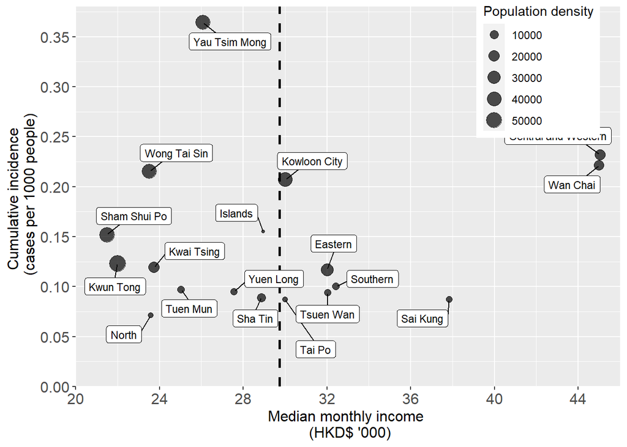

```r
Scatter_Total_CI_I<-ggplot(DD,aes(x=Income_1k, y=Cumulative.Incidence.Rate_percentage, size =population_density, label=District)) +
  geom_vline(xintercept=c(mean(DD$Income_1k)), linetype="dashed",lwd=1) +
  geom_label_repel(size = 3,min.segment.length = 0, box.padding = 0.5)+ geom_point(alpha=0.7)+
  xlab("Median monthly income \n (HKD$ '000)") + ylab("Cumulative incidence \n (cases per 1000 people)") + labs(size="Population density")
Scatter_Total_CI_I<-Scatter_Total_CI_I + scale_x_continuous(expand= c(0,0), limits = c(20,46),breaks = seq(20, 46, 4)) +
  scale_y_continuous(expand=c(0,0), limits=c(0,0.38), breaks= seq(0,0.35,0.05)) + labs(size="Population density")+
  theme(axis.text=element_text(size=12), axis.title = element_text(size = 12), legend.position = c(0.85,0.84))
Scatter_Total_CI_I
```

#case fatality rate(%) vs. median monthly income#

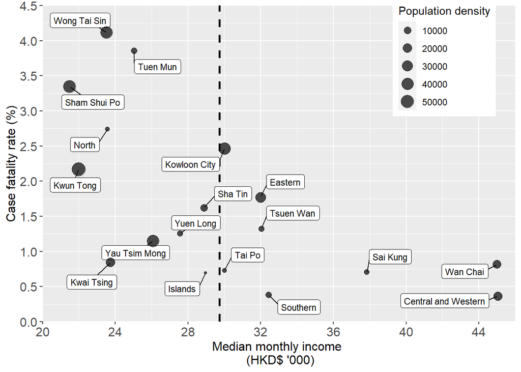

```r
Scatter_Total_CFR_I<-ggplot(DD,aes(x=Income_1k, y=cfr_percent, size =population_density, label=District)) +
  geom_vline(xintercept=c(mean(DD$Income_1k)), linetype="dashed",lwd=1) +
  geom_label_repel(size = 3,min.segment.length = 0, box.padding = 0.5)+ geom_point(alpha=0.7)+
  xlab("Median monthly income \n (HKD$ '000)") + ylab("Case fatality rate (%)")
Scatter_Total_CFR_I<-Scatter_Total_CFR_I + scale_x_continuous(expand= c(0,0), limits = c(20,46),breaks = seq(20, 46, 4)) +
  scale_y_continuous(expand=c(0,0), limits=c(0,4.5), breaks= seq(0,4.5,0.5)) + labs(size="Population density")+
  theme(axis.text=element_text(size=12), axis.title = element_text(size = 12), legend.position = c(0.85,0.835))
Scatter_Total_CFR_I
```

#cumulative incidence vs. population density#

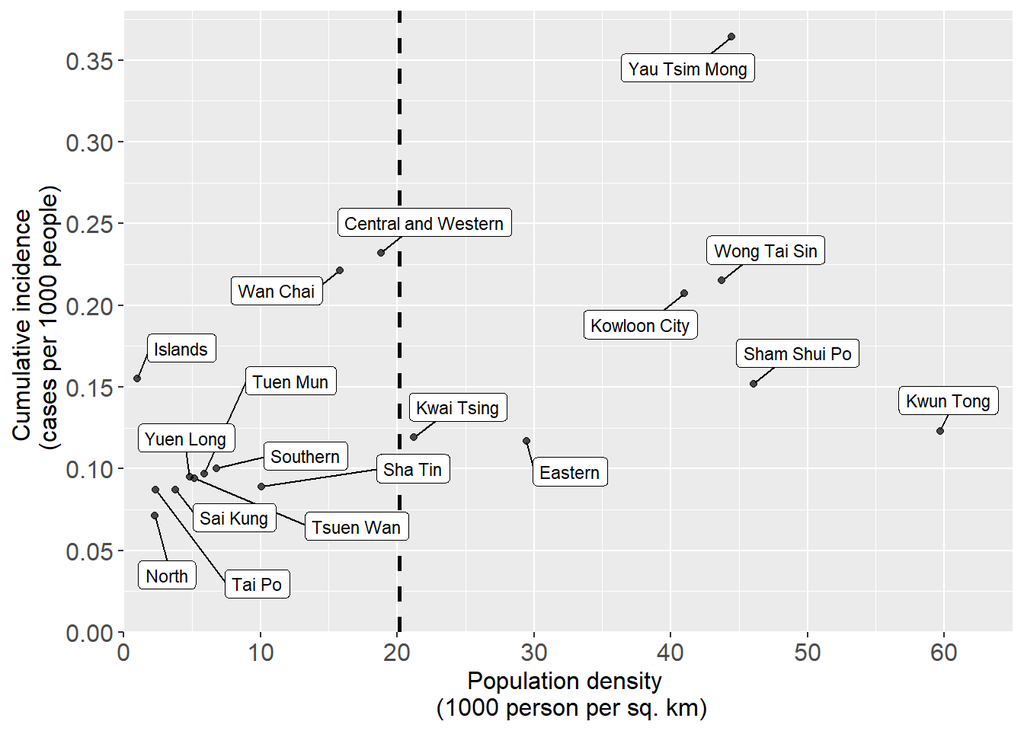

```r
Scatter_Total_CI_PD<-ggplot(DD,aes(x=population.density_1k, y=Cumulative.Incidence.Rate_percentage, label=District))+
  geom_vline(xintercept=c(mean(DD$population.density_1k)), linetype="dashed",lwd=1) +
  geom_label_repel(size = 3,min.segment.length = 0, box.padding = 0.5)+ geom_point(alpha=0.7)+
  xlab("Population density \n (1000 person per sq. km)") + ylab("Cumulative incidence \n (cases per 1000 people)")
Scatter_Total_CI_PD<-Scatter_Total_CI_PD + scale_x_continuous(expand= c(0,0), limits = c(0,65),breaks = seq(0, 60, 10)) +
  scale_y_continuous(expand=c(0,0), limits=c(0,0.38), breaks= seq(0,0.35,0.05))+
  theme(axis.text=element_text(size=12), axis.title = element_text(size = 12))
Scatter_Total_CI_PD
```

#case fatality vs population density#

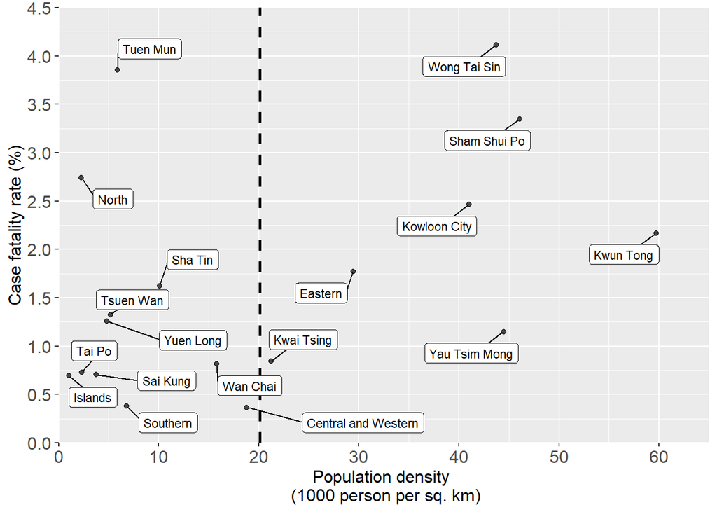

```r
Scatter_Total_CFR_PD<-ggplot(DD,aes(x=population.density_1k, y=cfr_percent, label=District)) +
  geom_vline(xintercept=c(mean(DD$population.density_1k)), linetype="dashed",lwd=1) +
  geom_label_repel(size = 3,min.segment.length = 0, box.padding = 0.5)+ geom_point(alpha=0.7)+
  xlab("Population density \n (1000 person per sq. km)") + ylab("Case fatality rate (%)")
Scatter_Total_CFR_PD<-Scatter_Total_CFR_PD + scale_x_continuous(expand= c(0,0), limits = c(0,65),breaks = seq(0, 60, 10)) +
  scale_y_continuous(expand=c(0,0), limits=c(0,4.5), breaks= seq(0,4.5,0.5))+
  theme(axis.text=element_text(size=12), axis.title = element_text(size = 12))
Scatter_Total_CFR_PD
```

To produce the combined scatter plot of the above four, run the following section:

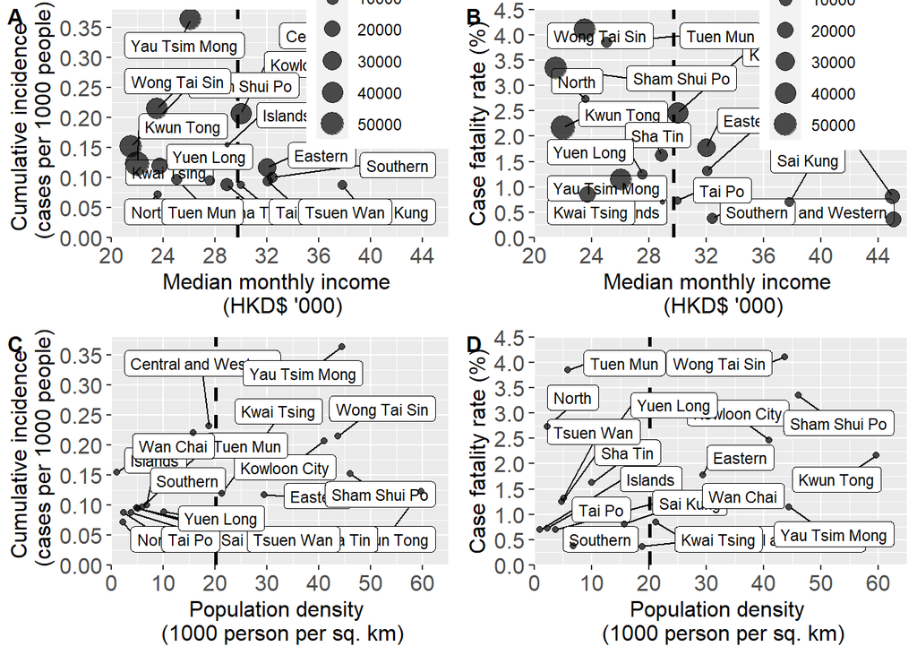

```r
FigureS6<-ggarrange(Scatter_Total_CI_I,Scatter_Total_CFR_I,Scatter_Total_CI_PD,Scatter_Total_CFR_PD,
                    labels = c("A","B","C","D"),font.label = list(size = 12),
                    ncol = 2, nrow = 2)
FigureS6
```

### CFR by income & density in symptomatic patients

Similarly, in order to find the scatter plots for the COVID-19 symptomatic patients, run the #Scatter Plot_Symptomatic# section. You will obtain the scatter plots of 1) cumulative incidence versus median monthly income, 2) case fatality rate vs monthly median income, 3)cumulative incidence vs population density and 4) case fatality vs population density for the symptomatic population.

##Scatter Plot_Symptomatic# #cumulative incidence vs. median monthly income#

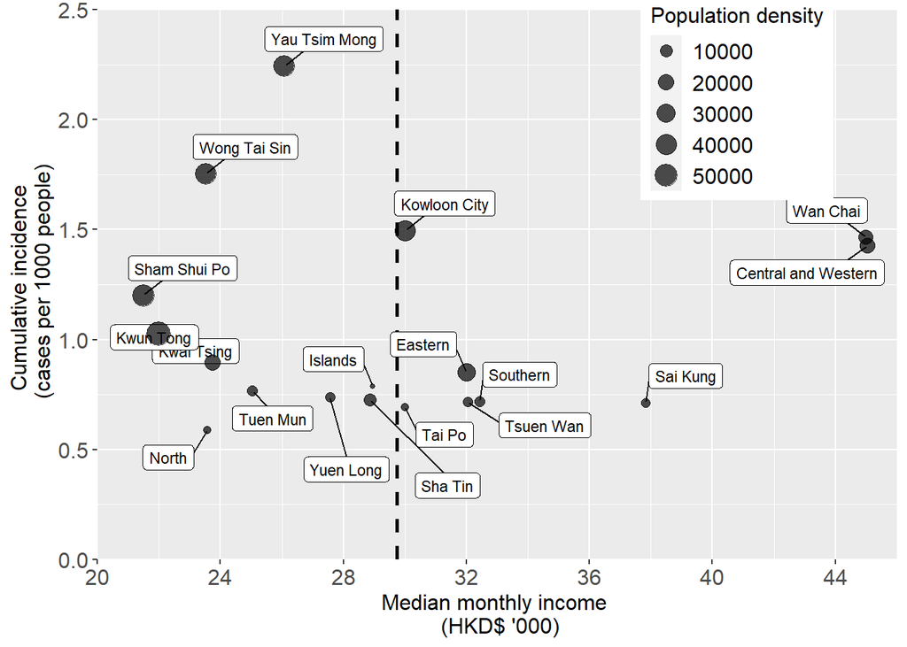

```r
Scatter_Symptomatic_CI_I<-ggplot(DS,aes(x=income_trans, y=inc_perk, size =population_density, label=District)) +
  geom_vline(xintercept=c(mean(DD$Income_1k)), linetype="dashed",lwd=1) +
  geom_label_repel(size = 3,min.segment.length = 0, box.padding = 0.5)+ geom_point(alpha=0.7)+
  xlab("Median monthly income \n (HKD$ '000)") + ylab("Cumulative incidence \n (cases per 1000 people)") + labs(size="Population density")
Scatter_Symptomatic_CI_I<-Scatter_Symptomatic_CI_I + scale_x_continuous(expand= c(0,0), limits = c(20,46),breaks = seq(20, 46, 4)) +
  scale_y_continuous(expand=c(0,0), limits=c(0,2.5), breaks= seq(0,2.5,0.5)) + labs(size="Population density")+
  theme(axis.text=element_text(size=12), axis.title = element_text(size = 12), legend.position = c(0.8,0.84),
        legend.title = element_text(size=12),legend.text = element_text(size=12))
Scatter_Symptomatic_CI_I
```

#case fatality vs median monthly income#

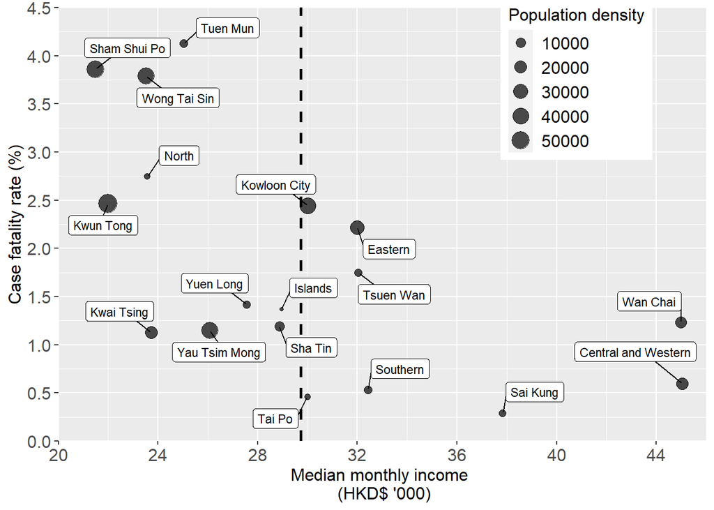

```r
Scatter_Symptomatic_CFR_I<-ggplot(DS,aes(x=income_trans, y=cfr_percent, size =population_density, label=District)) +
  geom_vline(xintercept=c(mean(DD$Income_1k)), linetype="dashed",lwd=1) +
  geom_label_repel(size = 3,min.segment.length = 0, box.padding = 0.5)+ geom_point(alpha=0.7) +
  xlab("Median monthly income \n (HKD$ '000)") + ylab("Case fatality rate (%)")
Scatter_Symptomatic_CFR_I<-Scatter_Symptomatic_CFR_I + scale_x_continuous(expand= c(0,0), limits = c(20,46),breaks = seq(20, 46, 4)) +
  scale_y_continuous(expand=c(0,0), limits=c(0,4.5), breaks= seq(0,4.5,0.5)) + labs(size="Population density")+
  theme(axis.text=element_text(size=12), axis.title = element_text(size = 12), legend.position = c(0.8,0.835),
        legend.title = element_text(size=12),legend.text = element_text(size=12))
Scatter_Symptomatic_CFR_I
```

#cumulative incidence vs. population density#

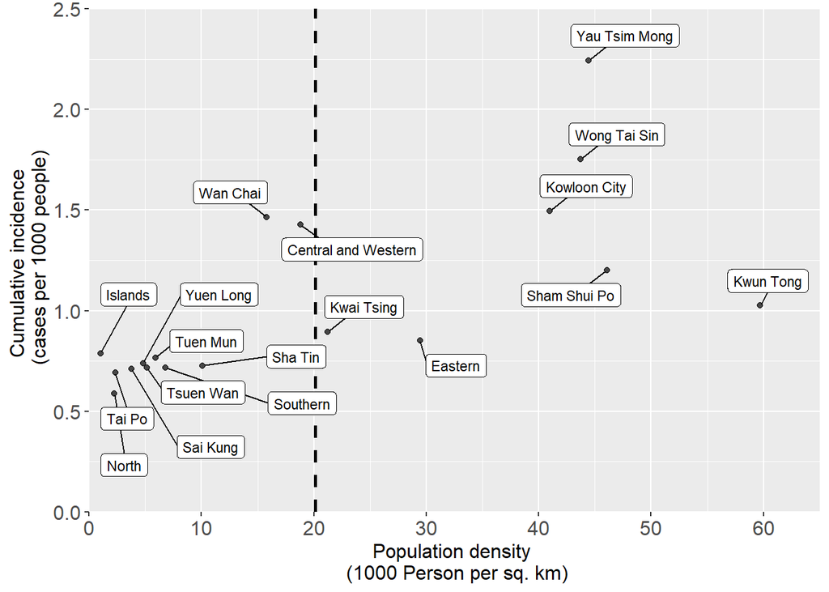

```r
Scatter_Symptomatic_CI_PD<-ggplot(DS,aes(x=population_density_1000, y=inc_perk, label=District)) +
  geom_vline(xintercept=c(mean(DD$population.density_1k)), linetype="dashed",lwd=1) +
  geom_label_repel(size = 3,min.segment.length = 0, box.padding = 0.5)+ geom_point(alpha=0.7) +
  xlab("Population density \n (1000 Person per sq. km)") + ylab("Cumulative incidence \n (cases per 1000 people)")
Scatter_Symptomatic_CI_PD<-Scatter_Symptomatic_CI_PD + scale_x_continuous(expand= c(0,0), limits = c(0,65),breaks = seq(0, 60, 10)) +
  scale_y_continuous(expand=c(0,0), limits=c(0,2.5), breaks= seq(0,2.5,0.5))+
  theme(axis.text=element_text(size=12), axis.title = element_text(size = 12))
Scatter_Symptomatic_CI_PD
```

#case fatality vs. population density#

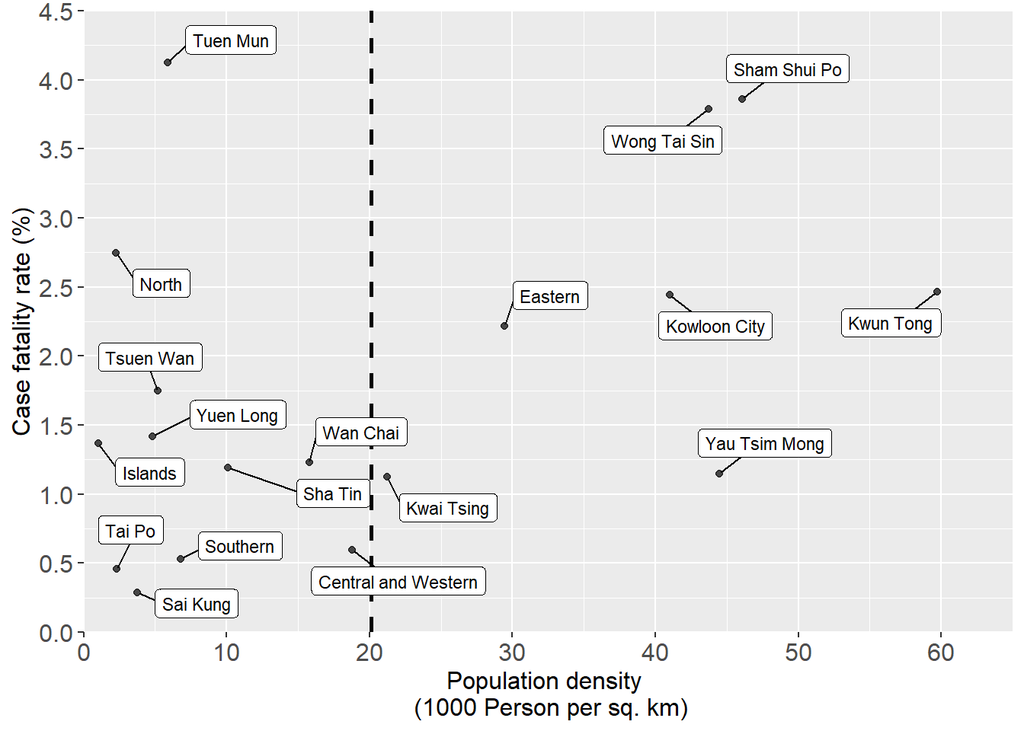

```r
Scatter_Symptomatic_CFR_PD<-ggplot(DS,aes(x=population_density_1000, y=cfr_percent, label=District)) +
  geom_vline(xintercept=c(mean(DD$population.density_1k)), linetype="dashed",lwd=1) +
  geom_label_repel(size = 3,min.segment.length = 0, box.padding = 0.5)+ geom_point(alpha=0.7)+
  xlab("Population density \n (1000 Person per sq. km)") + ylab("Case fatality rate (%)")
Scatter_Symptomatic_CFR_PD<-Scatter_Symptomatic_CFR_PD + scale_x_continuous(expand= c(0,0), limits = c(0,65),breaks = seq(0, 60, 10)) +
  scale_y_continuous(expand=c(0,0), limits=c(0,4.5), breaks= seq(0,4.5,0.5))+
  theme(axis.text=element_text(size=12), axis.title = element_text(size = 12))
Scatter_Symptomatic_CFR_PD
```

### CFR by income in elderly symptomatic patients

To produce a figure comparing the case fatality rate among elderly and symptomatic patients, run the following section.

#comparison case fatality rate in elderly vs.symptomatic patients#

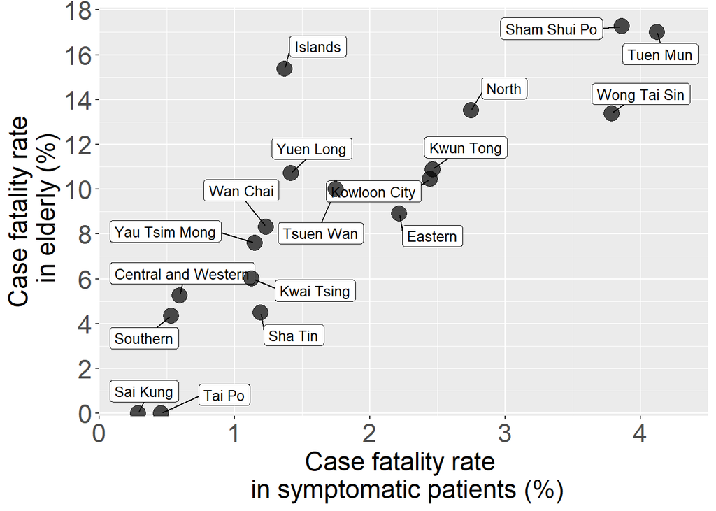

```r
Scatter_CFR_Comparsion<-ggplot(CFR_Overview,aes(x=cfr_percent, y=CFR_elderly, label=District)) +
  geom_label_repel(size = 3.5,min.segment.length = 0, box.padding = 0.5)+ geom_point(alpha=0.7,size=5)+
  xlab("Case fatality rate \n in symptomatic patients (%)") + ylab(" Case fatality rate \n in elderly (%)") +
  scale_x_continuous(expand= c(0,0), limits = c(0,4.5),breaks = seq(0, 4, 1)) +
  scale_y_continuous(expand=c(0,0.1), limits=c(0,18), breaks= seq(0,18,2))+
  theme(axis.text=element_text(size=18), axis.title = element_text(size = 18))
Scatter_CFR_Comparsion
```

#case fatality in elderly vs median monthly income#

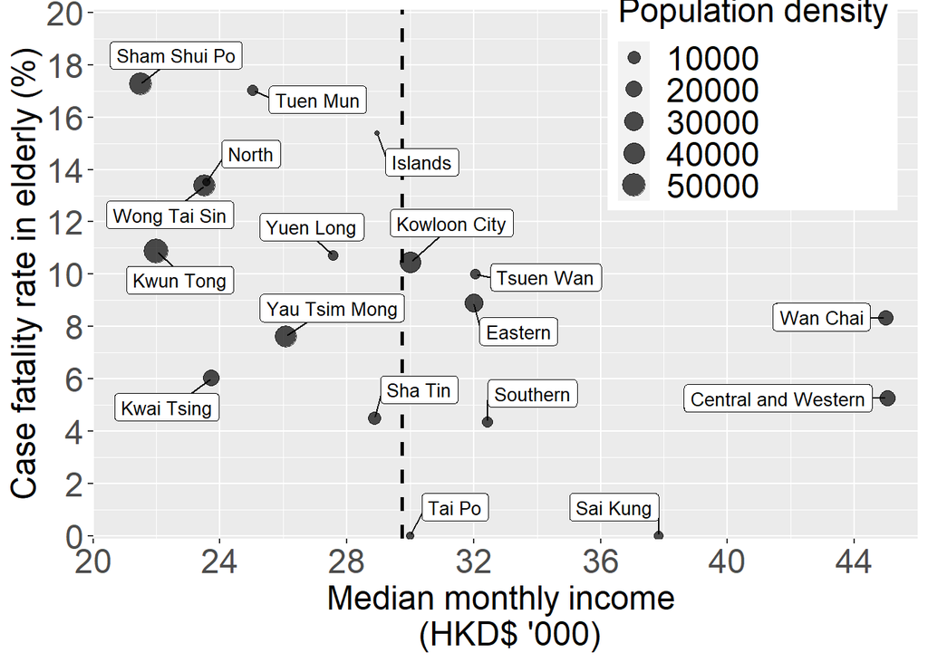

```r
Scatter_Symptomatic_Elderly_CFR_I<-ggplot(CFR_Overview,aes(x=income_trans, y=CFR_elderly, size =population_density, label=District)) +
  geom_vline(xintercept=c(mean(CFR_Overview$income_trans)), linetype="dashed",lwd=1) +
  geom_label_repel(size = 3.5,min.segment.length = 0, box.padding = 0.5)+ geom_point(alpha=0.7) +
  xlab("Median monthly income \n (HKD$ '000)") + ylab("Case fatality rate in elderly (%)") +
  scale_x_continuous(expand= c(0,0), limits = c(20,46),breaks = seq(20, 46, 4)) +
  scale_y_continuous(expand=c(0,0.1), limits=c(0,20), breaks= seq(0,20,2)) +
  labs(size="Population density")+
  theme(axis.text=element_text(size=18), axis.title = element_text(size = 18),
        legend.position = c(0.8,0.835), legend.title = element_text(size=18),
        legend.text = element_text(size=18))
Scatter_Symptomatic_Elderly_CFR_I
```

The following statement will reproduce the combined graph of the above two scatter diagram.

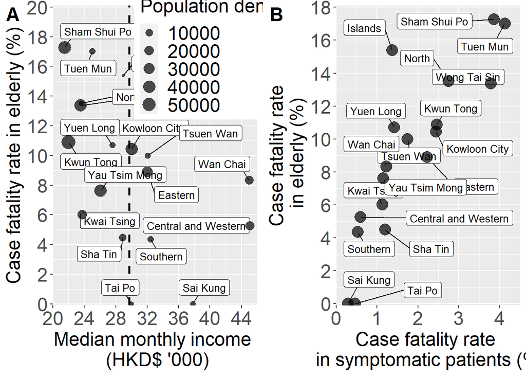

```r
FigureS2<-ggarrange(Scatter_Symptomatic_Elderly_CFR_I, Scatter_CFR_Comparsion,
                    labels = c("A","B"), font.label = list(size = 18),
                    nrow = 1)
FigureS2
```

### Distribution of people with chronic diseases

To obtain the bar diagrams of case fatality rate and people with chronic diseases in different territories, run the following Bar Chart_Symptomatic section.

##Bar Chart_Symptomatic #case fatality rate according to territories#

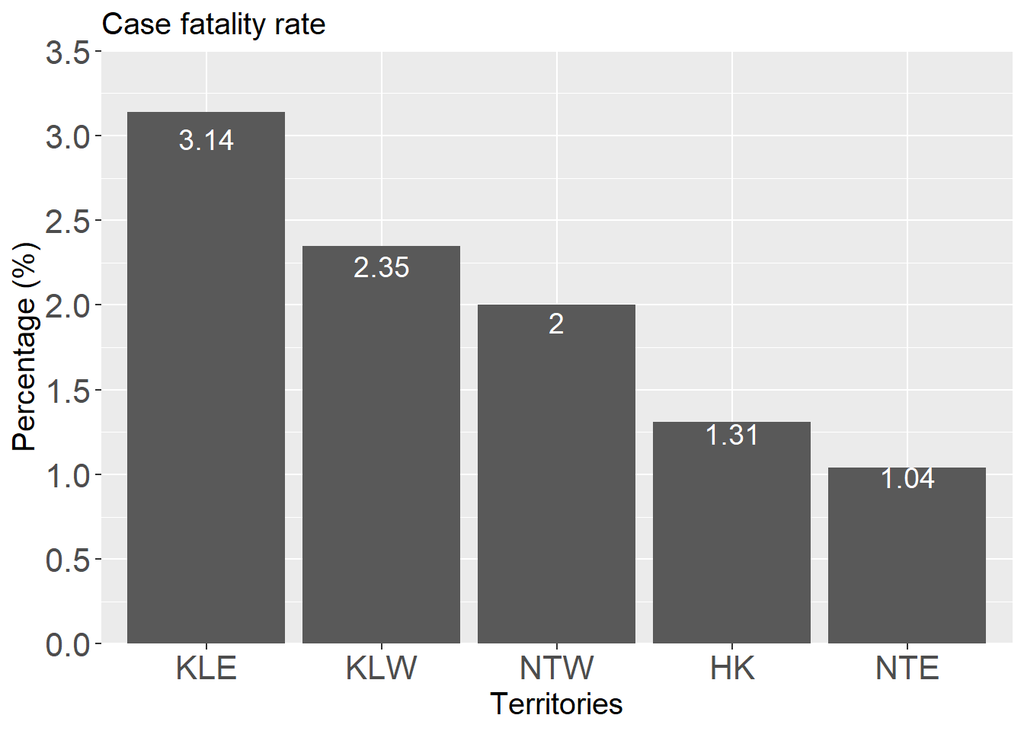

```r
level_order_TS<- factor(TS$Territory, level = c("KLE", "KLW", "NTW","HK","NTE"))
TS_CFR<-ggplot(TS, aes(x = level_order_TS, cfr,2, label=cfr)) +
  geom_bar(stat = "identity") +
  ggtitle("Case fatality rate") +
  xlab("Territories") +
  ylab("Percentage (%)") +
  geom_text(size = 5, position = position_stack(vjust =0.95), color="white") +
  scale_y_continuous(expand= c(0,0),breaks = seq(0, 3.5, 0.5)) + coord_cartesian(ylim = c(0, 3.5)) +
  theme(axis.text=element_text(size=16), axis.title = element_text(size = 15),plot.title = element_text(size = 15))
TS_CFR
```

#people with chronic diseases according to territories#

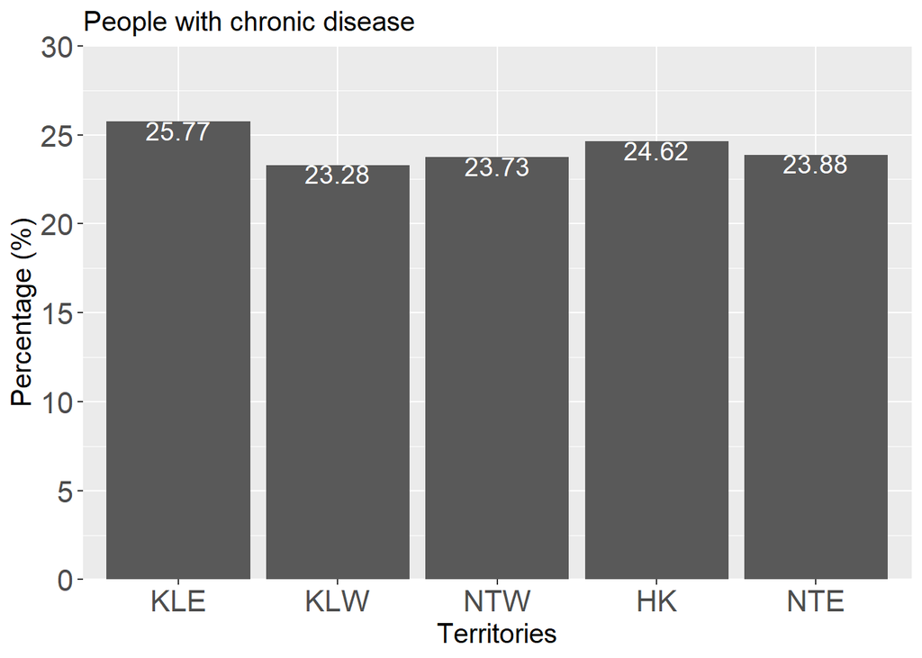

```r
TS_CDP<-ggplot(TS, aes(x = level_order_TS, y = CDPinPop_percent, label=CDPinPop_percent)) +
  geom_bar(stat = "identity") +
  ggtitle("People with chronic disease") + ylab("Percentage (%)") +
  xlab("Territories") +
  geom_text(size = 5, position = position_stack(vjust =0.98), color="white") +
  scale_y_continuous(expand= c(0,0),breaks = seq(0, 30, 5)) + coord_cartesian(ylim = c(0, 30)) +
  theme(axis.text=element_text(size=16), axis.title = element_text(size = 15),plot.title = element_text(size = 15))
TS_CDP
```

To compare the case fatality rate and the people with chronic diseases in different territories, run the following combined graph.

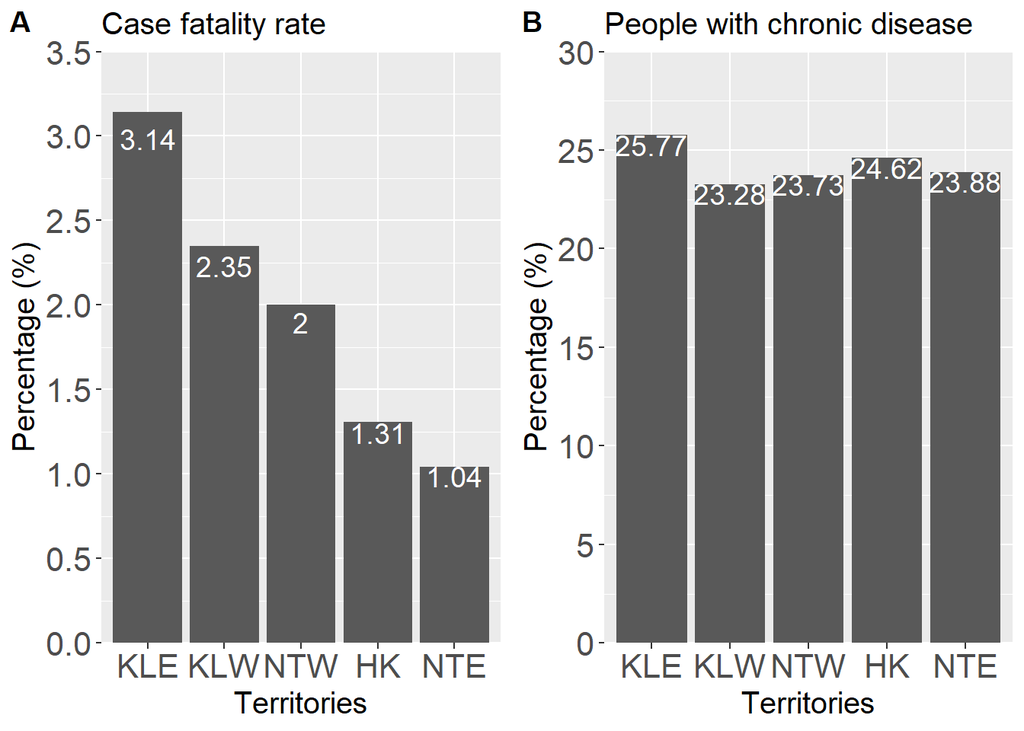

```r
FigureS3<-ggarrange(TS_CFR,TS_CDP,
                    labels = c("A","B"),
                    ncol = 2)
FigureS3
```

You can calculate the Pearson’s correlation between case fatality rate and chronic disease in different territories running the section below.

### Correlation between CFR and Proportion of people with chronic diseases

```r
cor(TS$cfr,TS$CDPinPop_percent,method="pearson")
```

```
## [1] 0.4571497
```

```r
cor.test(TS$cfr,TS$CDPinPop_percent)
```

```
##
##  Pearson's product-moment correlation
##
## data:  TS$cfr and TS$CDPinPop_percent
## t = 0.89028, df = 3, p-value = 0.4389
## alternative hypothesis: true correlation is not equal to 0
## 95 percent confidence interval:
##  -0.7124796  0.9544570
## sample estimates:
##       cor
## 0.4571497
```

### CFR by reporting delay & hospitalization time

For the demographic analysis of case fatality rate among reporting delay and hospitalization time, first you need to read the following data set using the codes below:

#CFR among reporting delay & hospitalization time

```r
Covid2<-read.csv("data/Covid model_symptomatic.csv")
Covid2_Delay<-read.csv("data/DeathRisk.csv")
Covid2_Delay2<-read.csv("data/DeathRisk_Individual.csv")
Covid2_agepercent<-read.csv("data/Covid model_symptomatic_2Income.csv")
Covid2_agepercent2<-read.csv("data/Covid model_symptomatic_70_2Income.csv")

Covid2$Income.Region<-factor(Covid2$Income.Region,levels=c("Low Income Region","Middle Income Region","High Income Region"))
Covid2$Grouped.Delay.Time <- factor(Covid2$Grouped.Delay.Time, level = c("0", "1", "2","3","4","5","6","7","8","9","10",">10"))

Covid2_agepercent$Income.Region<-factor(Covid2_agepercent$Income.Region,levels=c("High Income Region","Low and Middle Income Region"))
Covid2_agepercent$Gender.Age<-factor(Covid2_agepercent$Gender.Age,levels=c("Male(≤64 years old)","Female(≤64 years old)","Male(>64 years old)","Female(>64 years old)"))

Covid2_agepercent2$Income.Region<-factor(Covid2_agepercent2$Income.Region,levels=c("High Income Region","Low and Middle Income Region"))
Covid2_agepercent2$Gender.Age<-factor(Covid2_agepercent2$Gender.Age,levels=c("Male(≤69 years old)","Female(≤69 years old)","Male(>69 years old)","Female(>69 years old)"))
```

#Subset Data

```r
Covid2_65<-Covid2 %>% filter(is.na(Age) | Age >= 65)
Covid2_65$Income.Region<-factor(Covid2_65$Income.Region,levels=c("Low Income Region","Middle Income Region","High Income Region"))

Delay_Total_LMH<-Covid2 %>% group_by(Income.Region)%>%count(Grouped.Delay.Time)
Delay_Total_LMH<-Delay_Total_LMH %>% group_by(Income.Region) %>% mutate(percentage=n/sum(n)*100)

Delay_Elderly_LMH<-Covid2_65 %>% group_by(Income.Region) %>% count(Grouped.Delay.Time)
Delay_Elderly_LMH<-Delay_Elderly_LMH %>% group_by(Income.Region) %>% mutate(percentage=n/sum(n)*100)
Delay <- data.frame(Income.Region=c("High Income Region"),Grouped.Delay.Time=c(0),n=c(0),percentage=c(0))
Delay$Grouped.Delay.Time<-as.factor(Delay$Grouped.Delay.Time)
Delay_Elderly_LMH<-rbind(Delay_Elderly_LMH, Delay)
remove(Delay)

Covid2_Alive<-Covid2%>%group_by(Income.Region,event)%>%filter(any(event == "0"))%>% count(Hospitalization.time)%>% mutate(percentage=n/sum(n)*100)
Covid2_Dead<-Covid2%>%group_by(Income.Region,event)%>%filter(any(event == "1"))%>% count(Hospitalization.time)%>% mutate(percentage=n/sum(n)*100)
```

You can reproduce the scatter plots of case fatality rates and delay reporting time using the following r code section.

#CFR over delay time

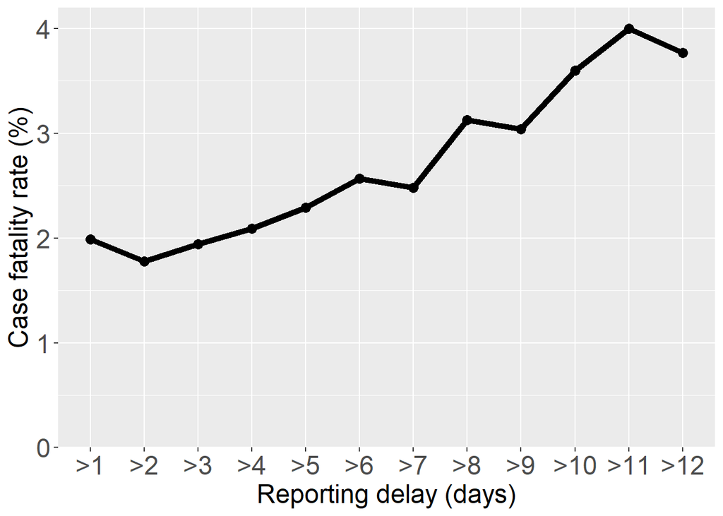

```r
Covid2_Delay$Delay.Time <- factor(Covid2_Delay$Delay.Time, level = c(">1",">2",">3",">4",">5",">6",">7",">8",">9",">10",">11",">12"))
CFR_delay<-ggplot(Covid2_Delay,aes(x=Delay.Time, y=cfr_percent, group=1)) + geom_point(size = 3) + geom_line(size = 2) +
  xlab("Reporting delay (days)") + ylab("Case fatality rate (%)") +
  scale_y_continuous(expand=c(0,0), limits=c(0,4.2), breaks= seq(0,4,1)) +
  theme(axis.text=element_text(size=18), axis.title = element_text(size = 18))
CFR_delay
```

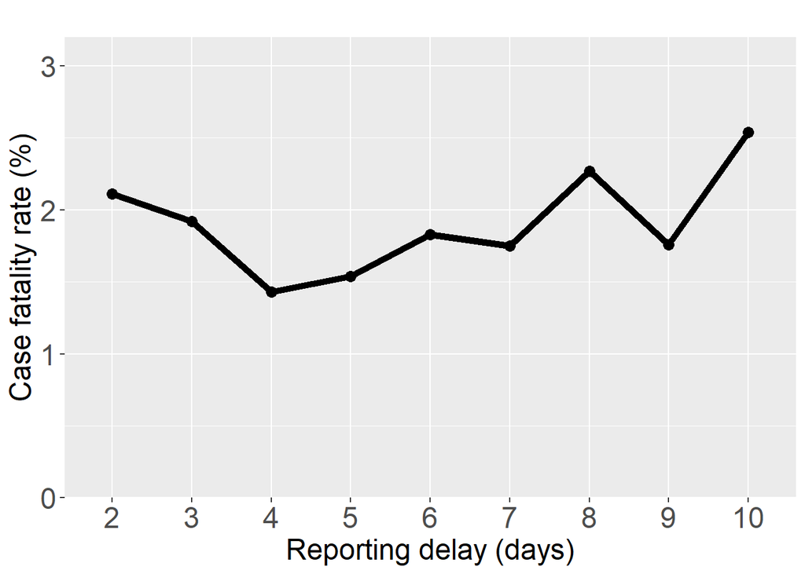

```r
Covid2_Delay2$Delay.time <- as.factor(Covid2_Delay2$Delay.time)
CFR_delay2<-ggplot(Covid2_Delay2,aes(x=Delay.time, y=CFR_3days,group=1)) + geom_point(size = 3) + geom_line(size = 2) +
  xlab("Reporting delay (days)") + ylab("Case fatality rate (%)") + ggtitle("") +
  scale_y_continuous(expand=c(0,0), limits=c(0,3.2), breaks= seq(0,3,1)) +
  theme(axis.text=element_text(size= 18), axis.title = element_text(size = 18))
CFR_delay2
```

You can also produce the combined graph of them using this code.

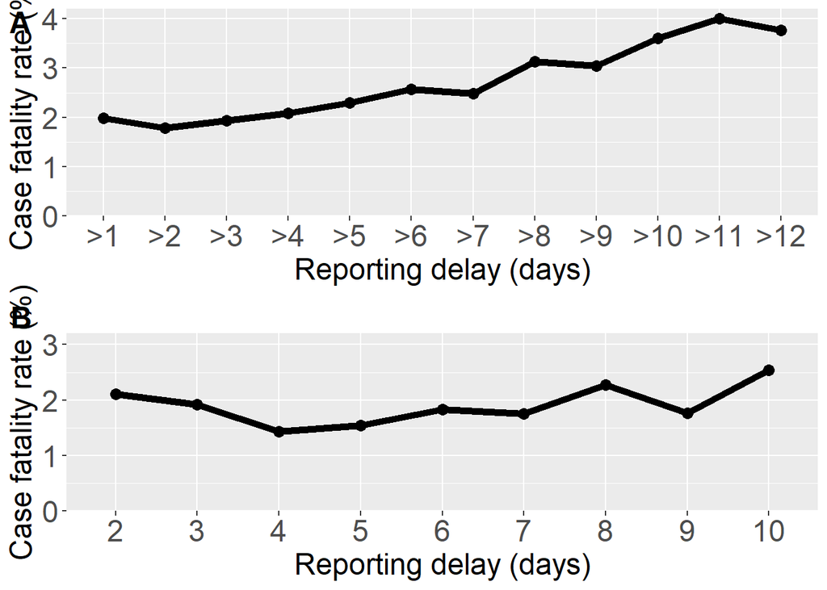

```r
Figure3AB<-ggarrange(CFR_delay, CFR_delay2,
                   labels = c("A","B"),font.label = list(size = 18),
                   ncol = 1)
Figure3AB
```

To see the bar diagrams of symptomatic patients from different income region against the percentage of severe delay time, proportion of delay time among elderly, run the following sections.

#Proportion of delayed reporting time of symptomatic patients#

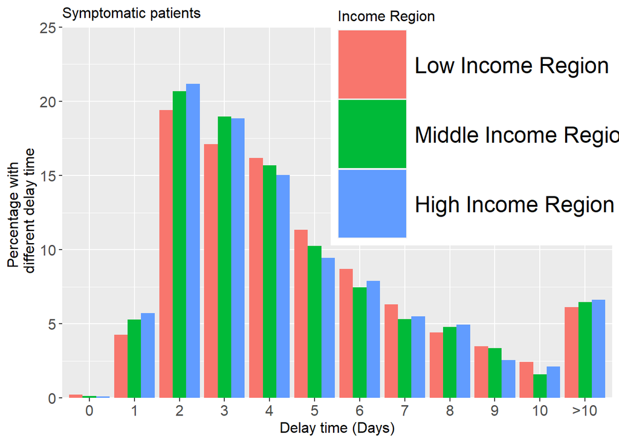

```r
level_order_Delay_Total  <- factor(Delay_Total_LMH$Grouped.Delay.Time, level = c("0", "1", "2","3","4","5","6","7","8","9","10",">10"))
Bar_Delay_Total_LMH<-ggplot(Delay_Total_LMH, aes(x=level_order_Delay_Total , y=percentage, label=percentage, fill = Income.Region, group = Income.Region)) + geom_bar(stat="identity", position = "dodge") +
  ggtitle("Symptomatic patients") + xlab("Delay time (Days)") +
  ylab("Percentage with \n different delay time") +
  scale_y_continuous(expand=c(0,0), limits = c(0, 25), breaks = seq(0, 25, 5)) + labs(fill="Income Region") +
  theme(plot.title = element_text(size=12), axis.text=element_text(size=12), axis.title = element_text(size = 12),
        legend.position = c(0.77,0.74), legend.key.size = unit(2,"cm"),legend.title = element_text(size=12),legend.text = element_text(size=18))
Bar_Delay_Total_LMH
```

#Proportion of delayed reporting time of elderly patients

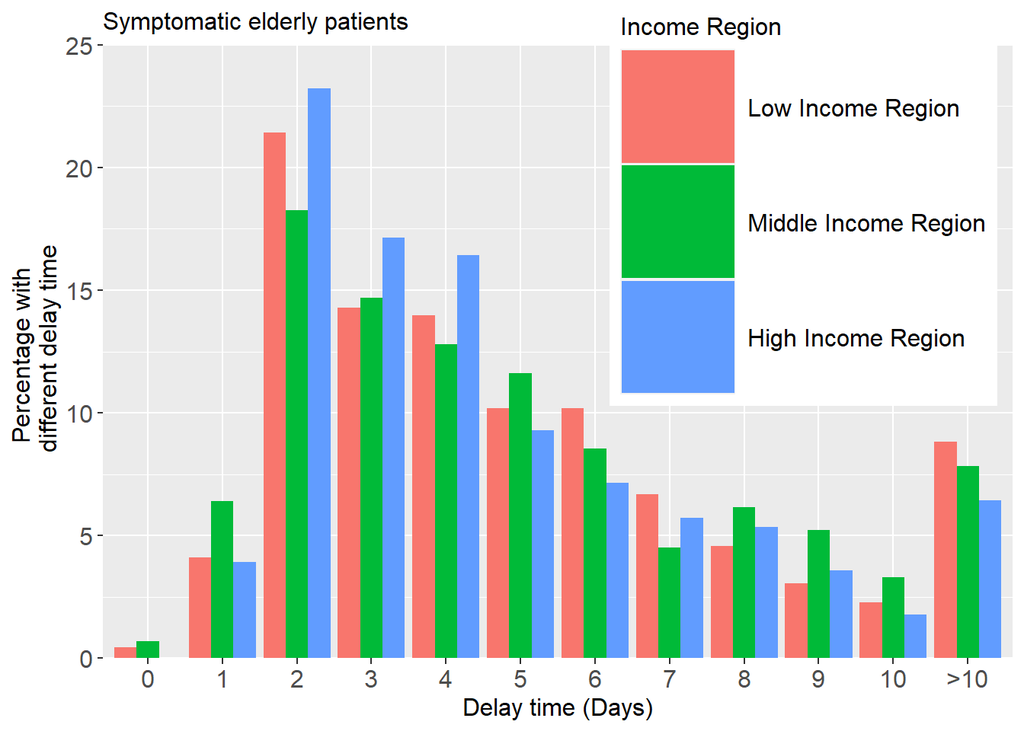

```r
Delay_Elderly_LMH$Income.Region<-factor(Delay_Elderly_LMH$Income.Region,levels=c("Low Income Region","Middle Income Region","High Income Region"))
level_order_Delay_Elderly <- factor(Delay_Elderly_LMH$Grouped.Delay.Time, level = c("0", "1", "2","3","4","5","6","7","8","9","10",">10"))

Bar_Delay_Elderly_LMH<-ggplot(Delay_Elderly_LMH, aes(x=level_order_Delay_Elderly , y=percentage, label=percentage, fill = Income.Region, group = Income.Region)) + geom_bar(stat="identity", position = "dodge") +
  ggtitle("Symptomatic elderly patients") + xlab("Delay time (Days)") + ylab("Percentage with \n different delay time") +
  scale_y_continuous(expand=c(0,0), limits = c(0, 25), breaks = seq(0, 25, 5)) + labs(fill="Income Region") +
  theme(plot.title = element_text(size=12), axis.text=element_text(size=12), axis.title = element_text(size = 12),
        legend.position = c(0.77,0.74), legend.key.size = unit(2,"cm"),legend.title = element_text(size=12),legend.text = element_text(size=12))
Bar_Delay_Elderly_LMH
```

#Percentage of severe delay patients

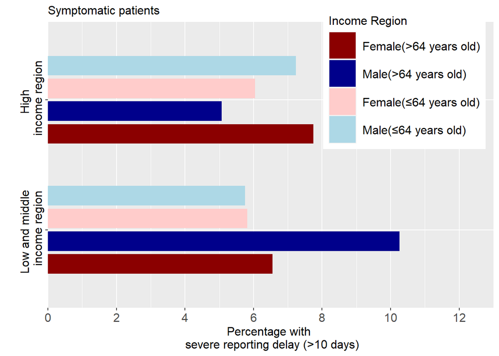

```r
my.labels <- c("Low and middle \n income region",
               "High \n income region")
Bar_Percentage<-ggplot(Covid2_agepercent, aes(x= fct_rev(Income.Region), y= Percentage_65, fill = fct_rev(Gender.Age))) +
  ggtitle("Symptomatic patients") + xlab("") + coord_flip() +
  ylab("Percentage with \n severe reporting delay (>10 days)") + scale_x_discrete(labels= my.labels) +
  geom_col(width = 0.6, position = position_dodge(0.7)) +
  scale_fill_viridis_d(breaks = rev, direction = -1) +
  scale_y_continuous(expand=c(0,0), limits = c(0, 13), breaks = seq(0, 12, 2)) + labs(fill="Income Region") +
  theme(plot.title = element_text(size=12), axis.text.x=element_text(size= 12),
        axis.title = element_text(size = 12), axis.text.y =element_text(size= 12, angle = 90,vjust = 0.7, hjust=0.5,color = "#000000"),
        legend.position = c(0.8,0.8), legend.key.size = unit(1,"cm"),
        legend.title = element_text(size=12),legend.text = element_text(size=12)) +
  scale_fill_manual(values = c("Male(≤64 years old)" = "#ADD8E6","Female(≤64 years old)" = "#ffcccb","Male(>64 years old)" = "#00008B","Female(>64 years old)" = "#8b0000"))
Bar_Percentage
```

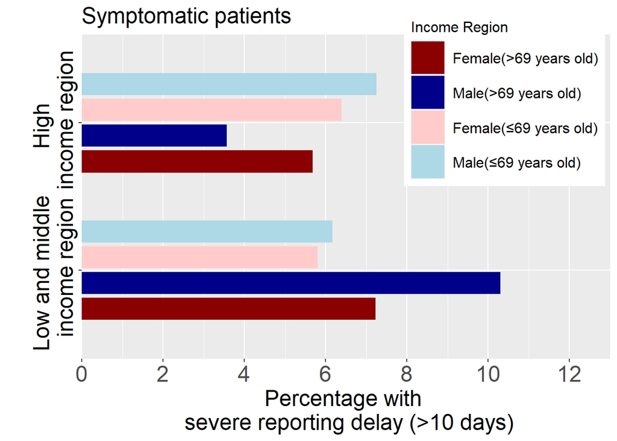

```r
Bar_Percentage_70<-ggplot(Covid2_agepercent2, aes(x= fct_rev(Income.Region), y= Percentage, fill = fct_rev(Gender.Age))) +
  ggtitle("Symptomatic patients") + xlab("") + coord_flip() +
  ylab("Percentage with \n severe reporting delay (>10 days)") + scale_x_discrete(labels= my.labels) +
  geom_col(width = 0.6, position = position_dodge(0.7)) +
  scale_fill_viridis_d(breaks = rev, direction = -1) +
  scale_y_continuous(expand=c(0,0), limits = c(0, 13), breaks = seq(0, 12, 2)) + labs(fill="Income Region") +
  theme(plot.title = element_text(size=18), axis.text.x=element_text(size= 18),
        axis.title = element_text(size = 18), axis.text.y =element_text(size= 18, angle = 90,vjust = 0.7, hjust=0.5,color = "#000000"),
        legend.position = c(0.8,0.8), legend.key.size = unit(1,"cm"),
        legend.title = element_text(size=12),legend.text = element_text(size=12)) +
  scale_fill_manual(values = c("Male(≤69 years old)" = "#ADD8E6","Female(≤69 years old)" = "#ffcccb","Male(>69 years old)" = "#00008B","Female(>69 years old)" = "#8b0000"))
Bar_Percentage_70
```

The following section will reproduce the combined graph of above three bar diagram.

[figure not shown]

```r
Figure3CDE<-ggarrange(Bar_Delay_Total_LMH,Bar_Delay_Elderly_LMH,Bar_Percentage,
                   labels = c("C","D","E"),
                   ncol = 1,nrow=3)
Figure3CDE
```

To get the combined histograms of the percentage of alive age group and percentage of dead age group against their hospitalization time based on the income level, run the #CFR over hospitalization time section.

##CFR over hospitalization time #Alive group distribution

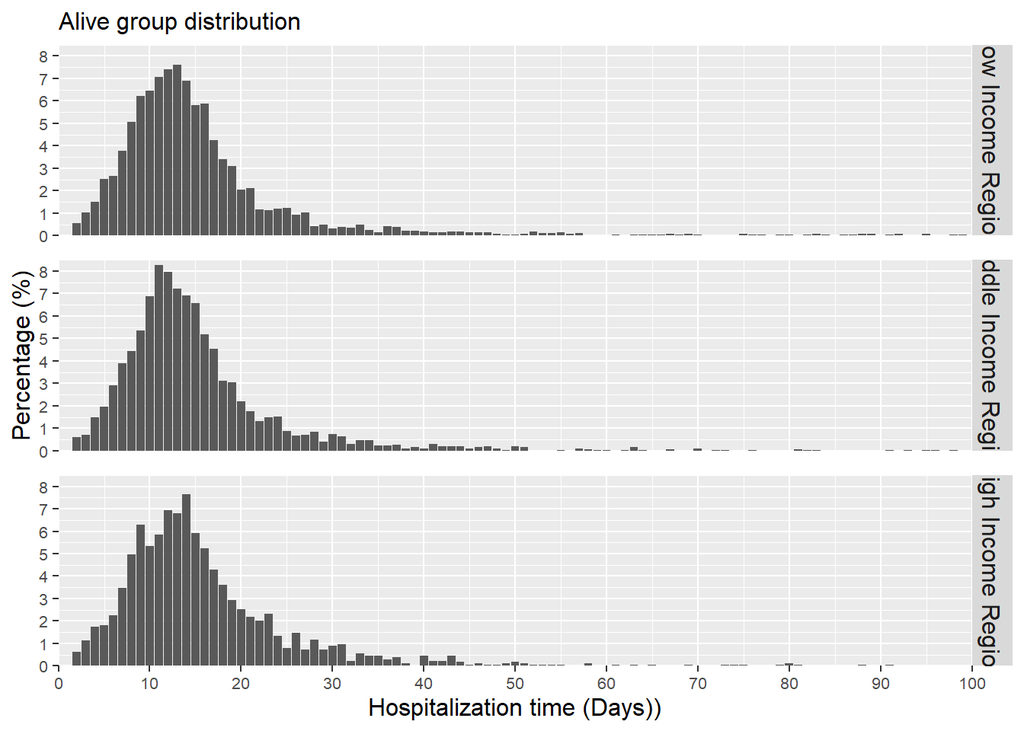

```r
Covid2_Alive.Hist<-ggplot(Covid2_Alive, aes(x=Hospitalization.time, y = percentage, label=percentage)) +
  scale_x_continuous(expand= c(0,0), limits = c(0,100),breaks = seq(0, 100, 10)) +
  geom_bar(stat = "identity") + scale_y_continuous(expand= c(0,0), limits = c(0,8.5),breaks = seq(0, 10, 1)) +
  facet_grid(factor(Income.Region, levels=c("Low Income Region", "Middle Income Region","High Income Region"))~.) +
  labs(title="Alive group distribution",x="Hospitalization time (Days))", y = "Percentage (%)") +
  theme(panel.spacing.y = unit(12, "pt"),strip.text.y = element_text(size = 12),
        axis.text=element_text(size=8), axis.title = element_text(size = 12),plot.title = element_text(size = 12))
Covid2_Alive.Hist
```

#Dead group distribution

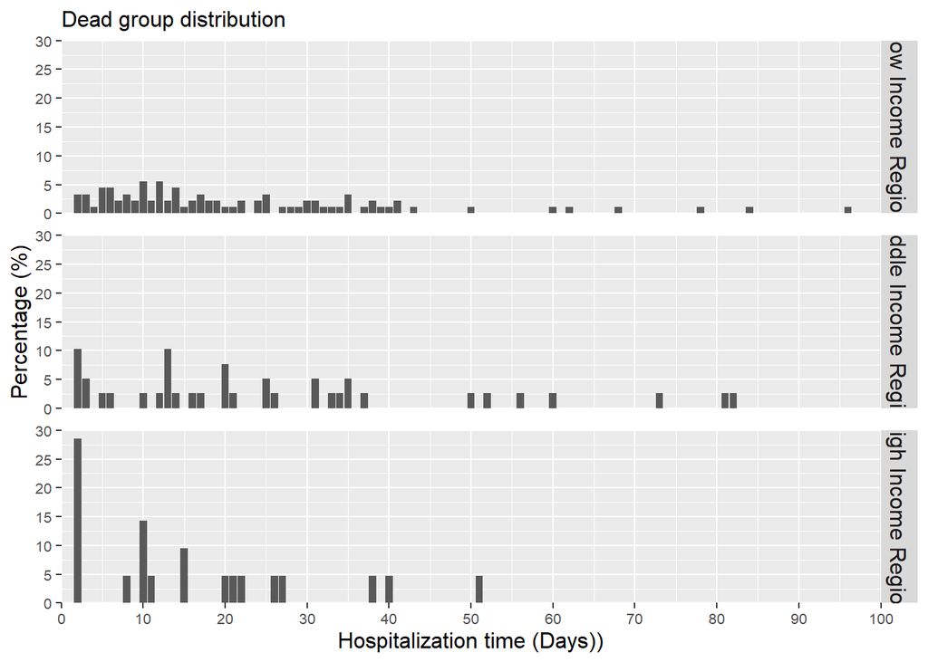

```r
Covid2_Dead.Hist<-ggplot(Covid2_Dead, aes(x=Hospitalization.time, y = percentage, label=percentage)) +
  scale_x_continuous(expand= c(0,0), limits = c(0,100),breaks = seq(0, 100, 10)) +
  geom_bar(stat = "identity") + scale_y_continuous(expand= c(0,0), limits = c(0,30),breaks = seq(0, 30, 5)) +
  facet_grid(factor(Income.Region, levels=c("Low Income Region", "Middle Income Region","High Income Region"))~.) +
  labs(title="Dead group distribution",x="Hospitalization time (Days))", y = "Percentage (%)") +
  theme(panel.spacing.y = unit(12, "pt"),strip.text.y = element_text(size = 12),
        axis.text=element_text(size=8), axis.title = element_text(size = 12),plot.title = element_text(size = 12))
Covid2_Dead.Hist
```

You can compare the both graphs for both alive and dead group of peoples using the following combined graph statements.

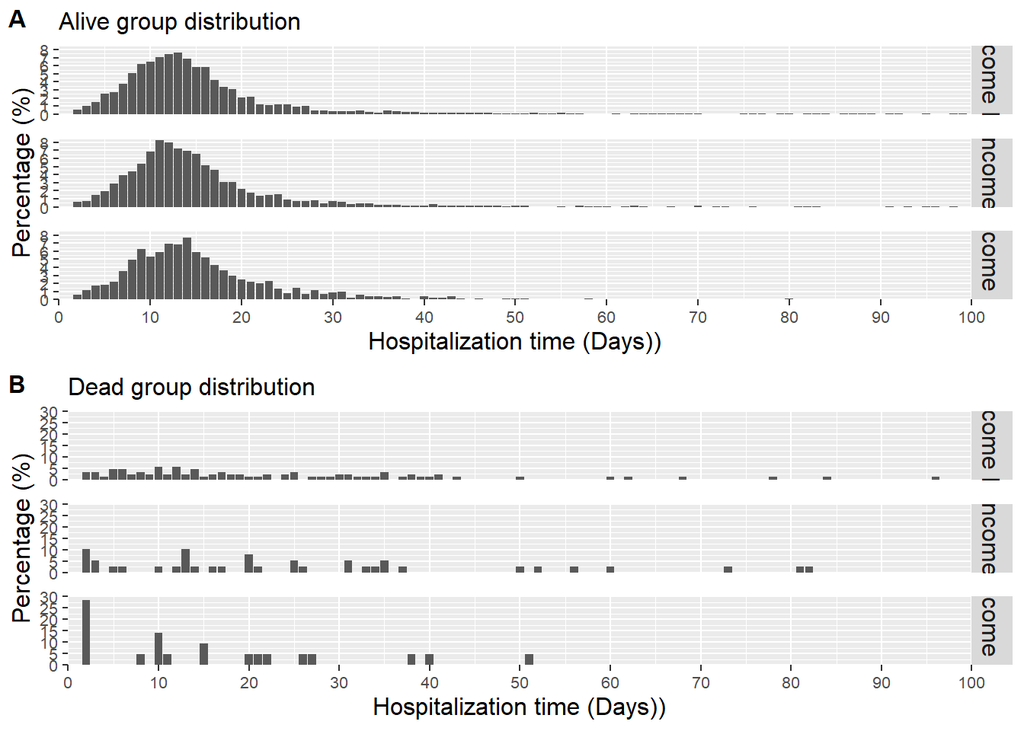

```r
FigureSA<-ggarrange(Covid2_Alive.Hist,Covid2_Dead.Hist,
                    labels = c("A","B"),font.label = list(size = 12),
                    ncol = 1, nrow = 2)
FigureSA
```

### Correlation between different variables

In order to find the correlation among the different variables of the data set, first you need to run the following data set.

##Correlation

```r
DD<-read.csv("data/dis_inc_cfr.csv")
DS<-read.csv("data/dis_inc_cfr_symptomatic.csv")
Covid<-read.csv("data/Covid model.csv")
Covid2<-read.csv("data/Covid model_symptomatic.csv")
Covid2_Dead<-Covid2%>%group_by(event)%>%filter(any(event=="1"))
```

Then for the construction of the correlation matrix run the sections below.

#Matrix

```r
df<-data.frame(DD$inc_perk,DD$cfr_percent,DD$population_density,DD$Income, DD$Average.Age,DD$Average.Patient.Age,DD$aht)
df2<-data.frame(DS$inc_perk,DS$cfr_percent,DS$population_density,DS$Income,DS$adt, DS$Average.Age,DS$Average.Patient.Age,DS$aht)
df3<-data.frame(Covid2$event,Covid2$Numeric.Gender,Covid2$Age,Covid2$Hospitalization.time,Covid2$Delay.Time)
df4<-data.frame(Covid2_Dead$Numeric.Gender,Covid2_Dead$Age,Covid2_Dead$Hospitalization.time,Covid2_Dead$Delay.Time)
```

#Correlation Function

```r
cor.mtest <- function(mat, ...) {
  mat <- as.matrix(mat)
  n <- ncol(mat)
  p.mat<- matrix(NA, n, n)
  diag(p.mat) <- 0
  for (i in 1:(n - 1)) {
    for (j in (i + 1):n) {
      tmp <- cor.test(mat[, i], mat[, j], ...)
      p.mat[i, j] <- p.mat[j, i] <- tmp$p.value
    }
  }
  colnames(p.mat) <- rownames(p.mat) <- colnames(mat)
  p.mat
}
```

#Correlation matrix between the CI, case fatality rate (CFR), median income,average age and average patient age#

```r
M1<-cor(df)
colnames(M1) <- c("CI", "CFR", "Population Density", "Median Income", "Average Age", "Average Patient Age","Average Hospitalization Time")
rownames(M1) <- c("CI", "CFR", "Population Density", "Median Income", "Average Age", "Average Patient Age","Average Hospitalization Time")
head(M1)
```

```
##                              CI         CFR Population Density Median Income
## CI                   1.00000000 -0.02401828          0.5476565     0.1759155
## CFR                 -0.02401828  1.00000000          0.4208685    -0.6131609
## Population Density   0.54765647  0.42086852          1.0000000    -0.3521903
## Median Income        0.17591548 -0.61316091         -0.3521903     1.0000000
## Average Age         -0.16330926  0.41245752          0.4024132    -0.2648041
## Average Patient Age -0.36024116  0.81765520          0.3088039    -0.6723318
##                     Average Age Average Patient Age
## CI                   -0.1633093          -0.3602412
## CFR                   0.4124575           0.8176552
## Population Density    0.4024132           0.3088039
## Median Income        -0.2648041          -0.6723318
## Average Age           1.0000000           0.6167394
## Average Patient Age   0.6167394           1.0000000
##                     Average Hospitalization Time
## CI                                    0.04652033
## CFR                                   0.48422477
## Population Density                    0.23038609
## Median Income                        -0.19387949
## Average Age                           0.45413299
## Average Patient Age                   0.52067136
```

#Plot of the matrix#

```r
p.mat <- cor.mtest(df)
colnames(p.mat) <- c("CI", "CFR", "Population Density", "Median Income", "Average Age", "Average Patient Age","Average Hospitalization Time")
rownames(p.mat) <- c("CI", "CFR", "Population Density", "Median Income", "Average Age", "Average Patient Age","Average Hospitalization Time")
head(p.mat)
```

```
##                             CI          CFR Population Density Median Income
## CI                  0.00000000 9.246339e-01         0.01863973   0.485026842
## CFR                 0.92463389 0.000000e+00         0.08199093   0.006811374
## Population Density  0.01863973 8.199093e-02         0.00000000   0.151757096
## Median Income       0.48502684 6.811374e-03         0.15175710   0.000000000
## Average Age         0.51731450 8.894760e-02         0.09780554   0.288272713
## Average Patient Age 0.14197216 3.407705e-05         0.21245706   0.002237653
##                     Average Age Average Patient Age
## CI                   0.51731450        1.419722e-01
## CFR                  0.08894760        3.407705e-05
## Population Density   0.09780554        2.124571e-01
## Median Income        0.28827271        2.237653e-03
## Average Age          0.00000000        6.407090e-03
## Average Patient Age  0.00640709        0.000000e+00
##                     Average Hospitalization Time
## CI                                    0.85456419
## CFR                                   0.04171860
## Population Density                    0.35771309
## Median Income                         0.44078592
## Average Age                           0.05833465
## Average Patient Age                   0.02673170
```

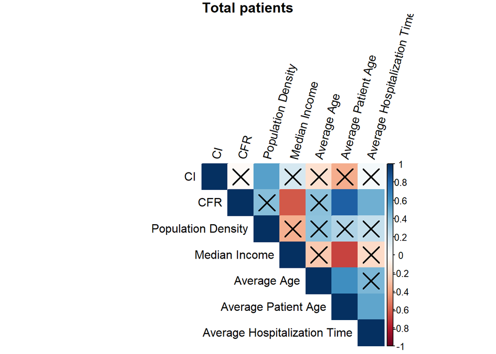

```r
FigureS1A<-corrplot(M1, method="color", tl.col="black", tl.srt=75, type="upper",p.mat = p.mat,
                    sig.level = 0.05, title = "Total patients",mar=c(0,0,1,0))
```

#Correlation matrix between the CI, case fatality rate (CFR), population density,median income, average delay time, average age, average patient age and average hospitalization time.#

```r
M2<-cor(df2)
colnames(M2) <- c("CI", "CFR", "Population Density", "Median Income", "Average Delay Time", "Average Age", "Average Patient Age", "Average Hospitalization Time")
rownames(M2) <- c("CI", "CFR", "Population Density", "Median Income", "Average Delay Time", "Average Age", "Average Patient Age", "Average Hospitalization Time")
head(M2)
```

```
##                             CI         CFR Population Density Median Income
## CI                  1.00000000  0.13841098          0.6790392    0.06899375
## CFR                 0.13841098  1.00000000          0.4324252   -0.59639736
## Population Density  0.67903916  0.43242525          1.0000000   -0.35219032
## Median Income       0.06899375 -0.59639736         -0.3521903    1.00000000
## Average Delay Time -0.42676945 -0.05341173         -0.2105265    0.02794970
## Average Age         0.01747458  0.37179198          0.4024132   -0.26480410
##                    Average Delay Time Average Age Average Patient Age
## CI                        -0.42676945  0.01747458         -0.13852730
## CFR                       -0.05341173  0.37179198          0.77582366
## Population Density        -0.21052648  0.40241317          0.34780904
## Median Income              0.02794970 -0.26480410         -0.65259708
## Average Delay Time         1.00000000 -0.05828376          0.07049406
## Average Age               -0.05828376  1.00000000          0.67114712
##                    Average Hospitalization Time
## CI                                   0.32446130
## CFR                                  0.30910103
## Population Density                   0.14449821
## Median Income                        0.07583343
## Average Delay Time                   0.06164032
## Average Age                          0.13083678
```

```r
p2.mat <- cor.mtest(df2)
colnames(p2.mat) <- c("CI", "CFR", "Population Density", "Median Income", "Average Delay Time", "Average Age", "Average Patient Age", "Average Hospitalization Time")
rownames(p2.mat) <- c("CI", "CFR", "Population Density", "Median Income", "Average Delay Time", "Average Age", "Average Patient Age", "Average Hospitalization Time")
head(p2.mat)
```

```
##                             CI         CFR Population Density Median Income
## CI                 0.000000000 0.583885442        0.001942483   0.785602746
## CFR                0.583885442 0.000000000        0.073092914   0.008989256
## Population Density 0.001942483 0.073092914        0.000000000   0.151757096
## Median Income      0.785602746 0.008989256        0.151757096   0.000000000
## Average Delay Time 0.077353768 0.833286973        0.401736899   0.912339381
## Average Age        0.945132410 0.128710377        0.097805538   0.288272713
##                    Average Delay Time Average Age Average Patient Age
## CI                         0.07735377  0.94513241        0.5835662713
## CFR                        0.83328697  0.12871038        0.0001543217
## Population Density         0.40173690  0.09780554        0.1572721980
## Median Income              0.91233938  0.28827271        0.0033276495
## Average Delay Time         0.00000000  0.81830991        0.7810468200
## Average Age                0.81830991  0.00000000        0.0022934415
##                    Average Hospitalization Time
## CI                                    0.1889720
## CFR                                   0.2119946
## Population Density                    0.5672825
## Median Income                         0.7648889
## Average Delay Time                    0.8080260
## Average Age                           0.6048237
```

#Plot of the matrix#

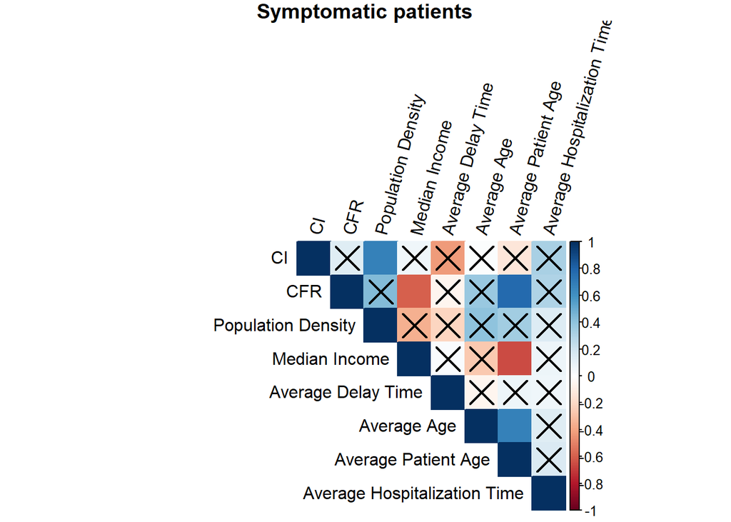

```r
FigureS1B<-corrplot(M2, method="color", tl.col="black", tl.srt=75, type="upper",p.mat = p2.mat,
                    sig.level = 0.05, title = "Symptomatic patients",mar=c(0,0,1,0))
```

#Correlation matrix between the decreased condition,gender,age, hospitalization time and report delay.#

```r
M3<-cor(df3)
head(M3)
```

```
##                             Covid2.event Covid2.Numeric.Gender  Covid2.Age
## Covid2.event                  1.00000000          0.0284218224  0.23860229
## Covid2.Numeric.Gender         0.02842182          1.0000000000 -0.02189078
## Covid2.Age                    0.23860229         -0.0218907821  1.00000000
## Covid2.Hospitalization.time   0.09654703          0.0830627811  0.18082831
## Covid2.Delay.Time             0.02063626          0.0002430967  0.06837898
##                             Covid2.Hospitalization.time Covid2.Delay.Time
## Covid2.event                                 0.09654703      0.0206362588
## Covid2.Numeric.Gender                        0.08306278      0.0002430967
## Covid2.Age                                   0.18082831      0.0683789818
## Covid2.Hospitalization.time                  1.00000000     -0.0609880462
## Covid2.Delay.Time                           -0.06098805      1.0000000000
```

```r
colnames(M3) <- c("Deceased Condition", "Gender", "Age", "Hospitalization Time", "Report Delay Time")
rownames(M3) <- c("Deceased Condition", "Gender", "Age", "Hospitalization Time", "Report Delay Time")
p3.mat <- cor.mtest(df3)
colnames(p3.mat) <- c("Deceased Condition", "Gender", "Age", "Hospitalization Time", "Report Delay Time")
rownames(p3.mat) <- c("Deceased Condition", "Gender", "Age", "Hospitalization Time", "Report Delay Time")
head(p3.mat)
```

```
##                      Deceased Condition       Gender          Age
## Deceased Condition         0.000000e+00 1.444471e-02 2.230425e-96
## Gender                     1.444471e-02 0.000000e+00 5.959376e-02
## Age                        2.230425e-96 5.959376e-02 0.000000e+00
## Hospitalization Time       8.311979e-17 8.103436e-13 1.809636e-55
## Report Delay Time          7.576474e-02 9.833119e-01 3.851027e-09
##                      Hospitalization Time Report Delay Time
## Deceased Condition           8.311979e-17      7.576474e-02
## Gender                       8.103436e-13      9.833119e-01
## Age                          1.809636e-55      3.851027e-09
## Hospitalization Time         0.000000e+00      1.500319e-07
## Report Delay Time            1.500319e-07      0.000000e+00
```

#Plot of the matrix#

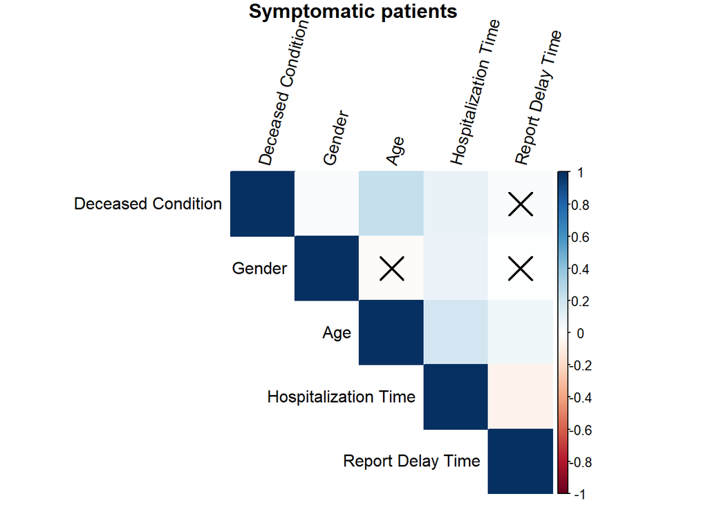

```r
Figure3F<-corrplot(M3, method="color", tl.col="black", tl.srt=75, type="upper",p.mat = p3.mat,
                    sig.level = 0.05, title = "Symptomatic patients",mar=c(0,0,1,0))
```

#Correlation matrix between the gender, age, hospitalization time, and report delay time in symptomatic deceased patients.#

```r
M4<-cor(df4)
head(M4)
```

```
##                                  Covid2_Dead.Numeric.Gender Covid2_Dead.Age
## Covid2_Dead.Numeric.Gender                       1.00000000     -0.07834638
## Covid2_Dead.Age                                 -0.07834638      1.00000000
## Covid2_Dead.Hospitalization.time                 0.15379909     -0.17677896
## Covid2_Dead.Delay.Time                           0.01980355     -0.20831047
##                                  Covid2_Dead.Hospitalization.time
## Covid2_Dead.Numeric.Gender                             0.15379909
## Covid2_Dead.Age                                       -0.17677896
## Covid2_Dead.Hospitalization.time                       1.00000000
## Covid2_Dead.Delay.Time                                 0.01522439
##                                  Covid2_Dead.Delay.Time
## Covid2_Dead.Numeric.Gender                   0.01980355
## Covid2_Dead.Age                             -0.20831047
## Covid2_Dead.Hospitalization.time             0.01522439
## Covid2_Dead.Delay.Time                       1.00000000
```

```r
colnames(M4) <- c("Gender", "Age", "Hospitalization Time", "Report Delay Time")
rownames(M4) <- c("Gender", "Age", "Hospitalization Time", "Report Delay Time")
p4.mat <- cor.mtest(df4)
colnames(p4.mat) <- c("Gender", "Age", "Hospitalization Time", "Report Delay Time")
rownames(p4.mat) <- c("Gender", "Age", "Hospitalization Time", "Report Delay Time")
head(p4.mat)
```

```
##                          Gender        Age Hospitalization Time
## Gender               0.00000000 0.34059917           0.06023291
## Age                  0.34059917 0.00000000           0.03046031
## Hospitalization Time 0.06023291 0.03046031           0.00000000
## Report Delay Time    0.80991354 0.01052594           0.85329894
##                      Report Delay Time
## Gender                      0.80991354
## Age                         0.01052594
## Hospitalization Time        0.85329894
## Report Delay Time           0.00000000
```

#Plot of the matrix#

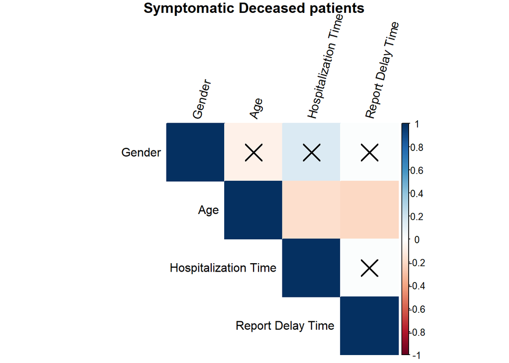

```r
FigureS4<-corrplot(M4, method="color", tl.col="black", tl.srt=75, type="upper",
                   p.mat = p4.mat, sig.level = 0.05,title = "Symptomatic Deceased patients",mar=c(0,0,1,0))
```